# ΜΙΣΤΑ002: Kruskal-Wallis H test

## Kruskal-Wallis H test

[figure not shown]

The Kruskal-Wallis H test is a rank-based nonparametric test that can be used to determine if there are statistically significant differences between two or more groups of an independent variable on a continuous dependent variable. It is considered the nonparametric alternative to the one-way ANOVA, and an extension of the Mann-Whitney U test to allow the comparison of more than two independent groups.

**Assumptions**

- random samples have been drawn from the respective populations or the participants have been randomly assigned to two conditions
- each measurement or observation must correspond to a different participant. In statistical terms, there is independence within groups and mutual independence between groups

**When the difference in the medians can be expressed in a null and alternative hypothesis?**

If the distributions have the same shape, the Kruskal-Wallis H test can be used to compare the medians of the dependent variable for the different groups of the independent variable of interest (as illustrated in the diagram on the left below). However, if the distributions have a different shape (as illustrated in the diagram on the right below), the Kruskal-Wallis H test should be regarded as a test of dominance between distributions comparing the mean ranks.

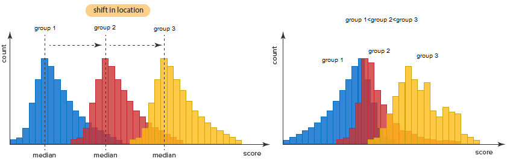

**Steps for conducting the test**

**Step 1. Define the null and alternative hypotheses under study**

**H<sub>0</sub>**: All k populations have the same median.

**H<sub>1</sub>**: Not all of the k populations medians are the same.

**Step 2. Calculate the value of the test statistic specific to H<sub>0</sub>**

The procedure for the test involves pooling the observations from the k samples into one combined sample, keeping track of which sample each observation comes from, and then ranking lowest to highest from 1 to N, where N = n<sub>1</sub>+n<sub>2</sub> + ...+ n<sub>k</sub>. Tied observations are assigned the mean of the ranks that would have received if they had not been tied. The Kruskal-Wallis H test statistic, if there are not many tied values, is given by:

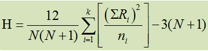

where ΣR<sub>i</sub> is the sum of the *i*<sup>th</sup>group.

*Tie correction for the Kruskal-Wallis H test statistic*

Some sources recommend that if there is an excessive number of ties in the overall distribution of N scores, the value of the Kruskal–Wallis test statistic have to be adjusted. The tie correction results in a small increase in the value of H (thus providing a slightly more powerful test of the alternative hypothesis).

**Step 3. Calculate the p-value**

Statistical software (e.g. R, SPSS) automatically provides the corresponding p-value that can be used for decision making.

**Step 4. Interpretation**

Interpretation of the results. If the null hypothesis is rejected, perform pairwise Mann-Whitney U tests, adjusting for multiple testing.

Worked Example

[figure not shown]

Quality-of-life scores, measured using the SF-36 questionnaire, were obtained in three groups of individuals: those with severe haemophilia, those with mild/moderate haemophilia, and normal controls. Each group comprised a sample of 20 individuals. Scores on the physical functioning scale (PFS), which can take values from 0 to 100, were compared in the three groups. As visual inspection of the below figure showed that the data were not Normally distributed, we performed a Kruskal–Wallis test (example from Petrie A. & Sabin C. 2005, Medical Statistics at a Glance, 2nd Ed., p.57).

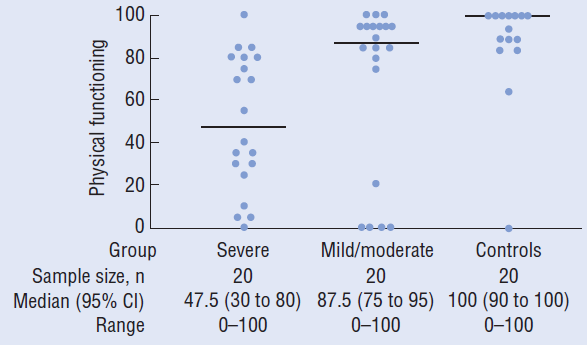

(figure reprinted from Petrie A. & Sabin C. 2005)

It is given that:

ΣR<sub>1</sub> (Sum of ranks in severe haemophilia group) = 372  
ΣR<sub>2</sub> (Sum of ranks in mild/moderate haemophilia group) = 599  
ΣR<sub>3</sub> (Sum of ranks in normal control group) = 859.

**Step 1. Define the null and alternative hypotheses under study**

**H<sub>0</sub>**: each group has the same PFS median.

**H<sub>1</sub>**: The PFS medians are different in each group.

**Step 2. Calculate the value of the test statistic specific to H<sub>0</sub>**

Τhe Kruskal-Wallis test statistic is calculated by H as follows:

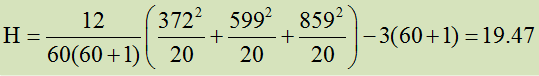

**Step 3. Compare the value of the test statistic to** **to the critical values of Kruskal-Wallis H**

For this example, H<sub>0</sub> is rejected because H=19.47 corresponds to a p<0.001.

**Step 4. Interpretation**  
There is substantial evidence to reject the null hypothesis that the distribution of PFS scores is the same in the three groups (p<0.001). Pairwise comparisons were carried out using Mann-Whitney U tests, adjusting the P-values for the number of tests performed using the Bonferroni correction. The individuals with severe (median = 47.5) and mild/moderate haemophilia (median=87.5) both had significantly lower PFS scores than the controls (median = 100), (P<sub>adj</sub> = 0.0003 and P<sub>adj</sub> = 0.03, respectively) but the distributions of the scores in the haemophilia groups were not significantly different from each other (P<sub>adj</sub> = 0.09).

*____________________________________*

*Aviva, P., Sabin, C. (2005). *Medical Statistics at a Glance* *(2<sup>nd</sup> Ed.)* UK: Blackwell Publishing.*

Last modified: Sunday, 6 May 2018, 10:19 PM